```r
weibo <- read.csv("Statistical Learning Data.csv", encoding = "UTF-8", stringsAsFactors = FALSE)
weibo$train_id <- sample(c("train", "valid"), nrow(weibo), replace = TRUE)
```

# Introduction

In late February of this year, the Korean government announced they were going to install an American-made anti-missile system in Korea, using land donated by the Korean company Lotte. Chinese citizens and the government were worried that this anti-missile system, called THAAD, could be used to spy on the Chinese government and military. In response to Korea’s announcement, Chinese citizens heavily protested Lotte’s products and stores, travel to Korea, and Korean celebrities.

There was a lot of nationalism during this period, with people saying, “Why would any Chinese person want to leave the country? China is strong, too” and promoting Chinese celebrities and brands.

When I was in China last semester, I was looking on Weibo (Chinese Twitter) and saw this post:

[figure not shown]

```r
library(png)
image <- readPNG("Anti Sehun Weibo.png")
par(mar = rep(0, 4L))
plot(0,0,xlim=c(0,1),ylim=c(0,1),axes= FALSE,type = "n",
     asp = nrow(image) / ncol(image))
rasterImage(image,0,0,1,1)
```

“How embarrassing~ A lot of famous Korean celebrities’ Weibo pages are already occupied by the enemy, some fans are yelling”unfollow“:”No idol comes before our country." Swipe through the most important parts of Sehun’s Weibo…“”

[figure not shown]

```r
image <- readPNG("Anti Sehun Weibo 2.png")
par(mar = rep(0, 4L))
plot(0,0,xlim=c(0,1),ylim=c(0,1),axes= FALSE,type = "n",
     asp = nrow(image) / ncol(image))
rasterImage(image,0,0,1,1)
```

“Bye Sehun, even though I really like you, no idol comes before our country. There’s no need for you to come to China just to get money anymore. Unfollowing.”

[figure not shown]

```r
image <- readPNG("Anti Sehun Weibo 3.png")
par(mar = rep(0, 4L))
plot(0,0,xlim=c(0,1),ylim=c(0,1),axes= FALSE,type = "n",
     asp = nrow(image) / ncol(image))
rasterImage(image,0,0,1,1)
```

“No idol comes before our country! Sorry Sehun, bye my beloved.”

“Sehun, I’m sorry.”

When I first saw this post, I was really confused. What is going on to make Chinese people hate on Korean celebrities?? As I read more into this “Lotte Incident,” as it’s called in China, I got a better understanding of why and how Chinese people were protesting everything.

Seeing how this incident even affected Korean celebrities’ Weibo pages, I wanted to see if I could look at celebrities who were poopular in Korea (both Chinese and Korean celebrities under contract in Korea) and see if I could see if any characteristics of their Weibo posts were indicative of whether that post was from before or after the announcement of the anti-missile system.

```r
library(ggplot2)
head(weibo$text)
```

```
## [1] "Xback 跟我亲爱的 姐 just dance tonight"
## [2] "我一个湖南人也想看迅哥加油 我们仨，一个四川人，一个河南人，一个东北人，来了这么一段散装粤语歌曲，见笑见笑，你只能凑合听啦！但是电影《东北往事之破马张飞》绝对是原装好货！千万别错过！"
## [3] "好久没跳舞了 想活动一下"
## [4] "翻到了一段很“远”的视频 祝大家 “圆”宵节快乐 团团圆圆 长长远远"
## [5] "哎…"
## [6] "今天我杀青 感谢各位演员 跟你们合作真的很开心 感谢《求婚大作战》所有工作人员为这部剧付出的努力 导演 摄像 制片 编剧 灯光 录音 外联 置景 美术 道具 场务 服装 梳化 跟组 群演 司机等等 相信因为大家的付出 播出时会呈现给大家大大的惊喜 此刻有些词穷 不知道如何表达我的心情 总之 大家一定 ..."
```

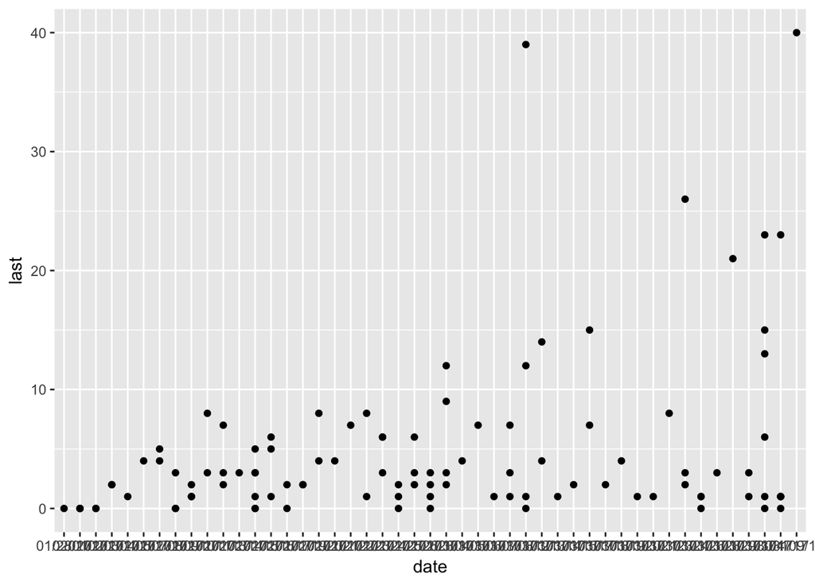

```r
ggplot(data = weibo, aes(x = date, y = last)) + geom_point()
```

One of the most indicative things seen here is that after the incident, many celebrities went a couple weeks without posting. For example, in March, the comments on one celebrity’s posts are:

[figure not shown]

```r
image <- readPNG("Victoria Weibo.png")
par(mar = rep(0, 4L))
plot(0,0,xlim=c(0,1),ylim=c(0,1),axes= FALSE,type = "n",
     asp = nrow(image) / ncol(image))
rasterImage(image,0,0,1,1)
```

“I missed you” “Goddess you finally reappeared ahhhhhhh” “Finally”

I want to clarify here that even with all the hate against everything Korean, celebrities still kept many of their fans during this time. I had to go a long way down the comments sections to even see anything anti-Korean.

# Model

```r
library(tokenizers)
library(smodels)
library(dplyr)
token_list <- tokenize_words(weibo$text)
token_df <- term_list_to_df(token_list)
filter(token_df, id == 2)
```

```
## # A tibble: 53 x 2
##       id token
##    <int> <chr>
##  1     2    我
##  2     2  一个
##  3     2  湖南
##  4     2    人
##  5     2    也
##  6     2  想看
##  7     2    迅
##  8     2    哥
##  9     2  加油
## 10     2  我们
## # ... with 43 more rows
```

```r
library(glmnet)
X <- term_df_to_matrix(token_df)
y <- weibo$after
X_train <- X[weibo$train_id == "train",]
y_train <- y[weibo$train_id == "train"]

model <- cv.glmnet(X, y, nfolds = 5, family = "binomial")

weibo$after_pred <- predict(model, newx = X, type = "class")
tapply(weibo$after_pred == weibo$after, weibo$train_id, mean)
```

```
##     train     valid
## 0.5686275 0.5961538
```

```r
model2 <- glm(after ~ poly(last, 6) + idol, data = weibo, subset = train_id == "train", family = binomial(link = "logit"))
weibo$after_pred2 <- predict(model2, newdata = weibo, type = "response")
weibo$after_pred2 <- as.numeric(weibo$after_pred2 > 0.5)
tapply(weibo$after_pred2 == weibo$after, weibo$train_id, mean)
```

```
##     train     valid
## 0.7647059 0.5769231
```

# Reflection

Since I collected this data myself, I know exactly what each post says (except for the super long ones–I didn’t actually read those), and I can tell why glmnet was not able to get any unique characteristics from the text of the posts alone.

1. Celebrities’ social media is really boring

Unless you’re there for the pictures, which I didn’t include, all of the posts are just celebrities promoting themselves or saying how thankful they are for their fans. I saw one nationalist post from a Chinese celebrity after the Lotte Incident started, but that was literally it.

2. Korean people don’t know Chinese. Or use Weibo

I only found 9 celebrities who were popular on Weibo and posted often. Of them, 3 were Chinese. I only had 103 posts total, which really wasn’t enough for analysis.